# Lab #6 KNN

# Métrica de distancia óptima y análisis del valor de P

| Valor de p | Métrica equivalente | Comportamiento |
| --- | --- | --- |
| **p = 1** | Manhattan (City-block) | Suma de diferencias absolutas; robusta a outliers. |
| **p = 2** | Euclidiana | Distancia geométrica clásica; sensible a la escala. |
| **p = 3+** | Minkowski generalizada | Acentúa las dimensiones con mayor diferencia. |

## Comparación sistemática del valor de p en regresión

```r
set.seed(123)

p_values <- c(1, 2, 3)

k_best       <- modelo_knn_tune_reg$bestTune$kmax
kernel_best  <- as.character(modelo_knn_tune_reg$bestTune$kernel)

set.seed(123)
idx_p_reg <- sample(seq_len(nrow(train_sc)), size = min(2500, nrow(train_sc)))
train_p_reg <- train_sc[idx_p_reg, ]

resultados_p_reg <- data.frame()

for (p_v in p_values) {
  modelo_p <- kknn(price ~ ., train = train_p_reg, test = test_sc,
                   k = k_best, distance = p_v, kernel = kernel_best)
  pred_p   <- modelo_p$fitted.values
  rmse_p   <- sqrt(mean((test_sc$price - pred_p)^2))
  mae_p    <- mean(abs(test_sc$price - pred_p))

  resultados_p_reg <- rbind(resultados_p_reg,
                            data.frame(p = p_v,
                                       RMSE = round(rmse_p, 2),
                                       MAE  = round(mae_p,  2)))
}

knitr::kable(resultados_p_reg,
             caption = "RMSE y MAE en regresión según el valor de p",
             align   = c("c","r","r")) %>%
  kable_styling(bootstrap_options = c("striped","condensed"), full_width = FALSE) %>%
  row_spec(which.min(resultados_p_reg$RMSE), bold = TRUE,
           color = "white", background = "#1a9641")
```

RMSE y MAE en regresión según el valor de p

| p | RMSE | MAE |
| --- | --- | --- |
| 1 | 3336.79 | 572.19 |
| 2 | 3762.26 | 631.43 |
| 3 | 3778.43 | 643.19 |

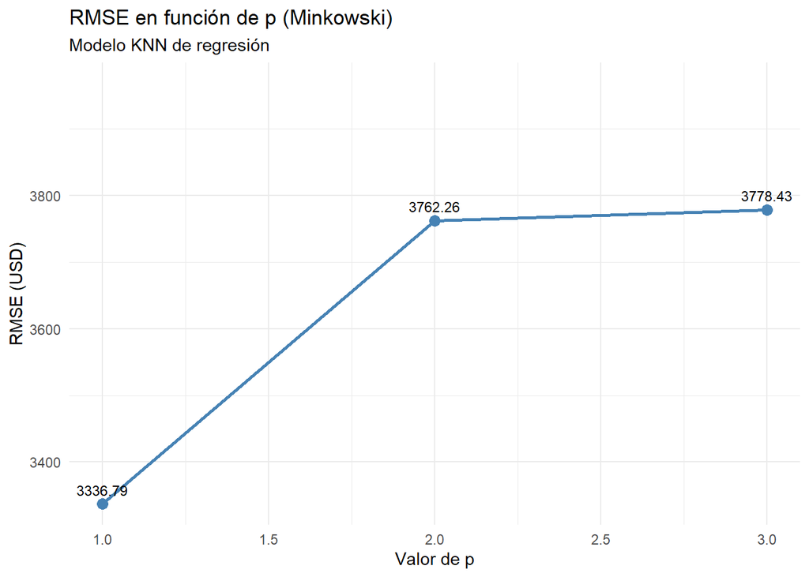

```r
ggplot(resultados_p_reg, aes(x = p, y = RMSE)) +
  geom_line(color = "steelblue", linewidth = 1) +
  geom_point(color = "steelblue", size = 3) +
  geom_text(aes(label = RMSE), vjust = -0.8, size = 3.2) +
  labs(title    = "RMSE en función de p (Minkowski)",
       subtitle = "Modelo KNN de regresión",
       x = "Valor de p", y = "RMSE (USD)") +
  theme_minimal() +
  expand_limits(y = max(resultados_p_reg$RMSE) * 1.05)
```

## Comparación sistemática del valor de p en clasificación

```r
set.seed(123)

k_best_clf      <- modelo_knn_tune_clf$bestTune$kmax
kernel_best_clf <- as.character(modelo_knn_tune_clf$bestTune$kernel)

set.seed(123)
idx_p_clf <- caret::createDataPartition(
  train_cat_clf$precio_cat,
  p = min(2500/nrow(train_cat_clf), 1),
  list = FALSE
)
train_p_clf <- train_cat_clf[idx_p_clf, ]

resultados_p_clf <- data.frame()

for (p_v in p_values) {
  modelo_pc <- kknn(precio_cat ~ ., train = train_p_clf, test = test_cat_clf,
                    k = k_best_clf, distance = p_v, kernel = kernel_best_clf)
  pred_pc   <- modelo_pc$fitted.values
  acc_pc    <- mean(pred_pc == test_cat_clf$precio_cat)

  resultados_p_clf <- rbind(resultados_p_clf,
                            data.frame(p = p_v,
                                       Accuracy = round(acc_pc, 4)))
}

knitr::kable(resultados_p_clf,
             caption = "Accuracy en clasificación según el valor de p",
             align   = c("c","r")) %>%
  kable_styling(bootstrap_options = c("striped","condensed"), full_width = FALSE) %>%
  row_spec(which.max(resultados_p_clf$Accuracy), bold = TRUE,
           color = "white", background = "#1a9641")
```

Accuracy en clasificación según el valor de p

| p | Accuracy |
| --- | --- |
| 1 | 0.6486 |
| 2 | 0.6300 |
| 3 | 0.6222 |

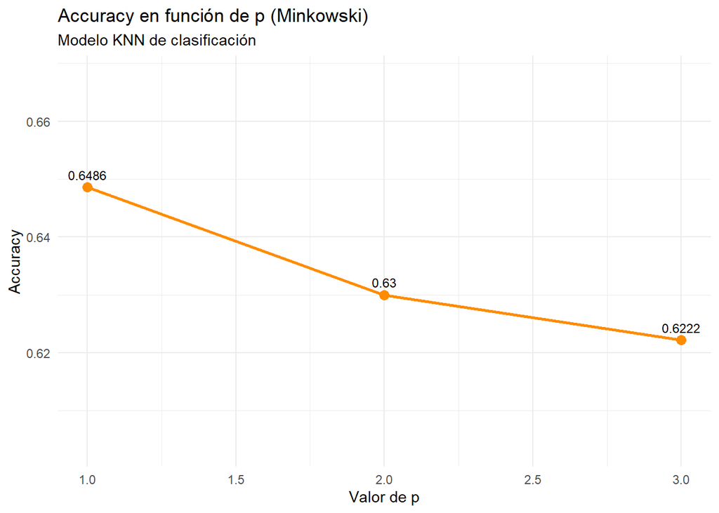

```
## Mejor valor de p (regresión)    : 1
```

```
## Mejor valor de p (clasificación): 1
```

```r
ggplot(resultados_p_clf, aes(x = p, y = Accuracy)) +
  geom_line(color = "darkorange", linewidth = 1) +
  geom_point(color = "darkorange", size = 3) +
  geom_text(aes(label = Accuracy), vjust = -0.8, size = 3.2) +
  labs(title    = "Accuracy en función de p (Minkowski)",
       subtitle = "Modelo KNN de clasificación",
       x = "Valor de p", y = "Accuracy") +
  theme_minimal() +
  expand_limits(y = c(min(resultados_p_clf$Accuracy)*0.97,
                      max(resultados_p_clf$Accuracy)*1.03))
```

La métrica resaltada en verde en cada tabla es la que produjo el mejor desempeño. En la mayoría de problemas con variables numéricas escaladas, la **distancia de Manhattan (p = 1)** o la **Euclidiana (p = 2)** suelen ser las más eficientes. Las variables predictoras del dataset son numéricas pero de naturaleza heterogénea (conteos discretos y ratios). La distancia de Manhattan trata cada dimensión de forma aditiva e independiente, lo que es coherente con esta heterogeneidad. Valores de p mayores a 2 amplifican las diferencias en la dimensión más extrema, lo que en presencia de ruido empeora la predicción.

# Comparación final con árbol de decisión, Random Forest y Naive Bayes

```r
set.seed(123)

t0 <- Sys.time()
modelo_arbol_clf <- rpart(precio_cat ~ . - price,
                          data = train_cat, method = "class",
                          control = rpart.control(xval = 10))
cp_opt_clf <- modelo_arbol_clf$cptable[which.min(
                modelo_arbol_clf$cptable[, "xerror"]), "CP"]
modelo_arbol_clf <- prune(modelo_arbol_clf, cp = cp_opt_clf)
t_arbol <- as.numeric(difftime(Sys.time(), t0, units = "secs"))

pred_arbol_clf <- predict(modelo_arbol_clf, newdata = test_cat, type = "class")
cm_arbol_clf   <- confusionMatrix(pred_arbol_clf, test_cat$precio_cat)

set.seed(123)
idx_rf <- sample(seq_len(nrow(train_cat)), size = min(10000, nrow(train_cat)))
train_rf <- train_cat[idx_rf, ]

t0 <- Sys.time()
modelo_rf <- randomForest(precio_cat ~ . - price,
                          data = train_rf, ntree = 100)
t_rf <- as.numeric(difftime(Sys.time(), t0, units = "secs"))

pred_rf <- predict(modelo_rf, newdata = test_cat)
cm_rf   <- confusionMatrix(pred_rf, test_cat$precio_cat)

t0 <- Sys.time()
modelo_nb_t <- naiveBayes(precio_cat ~ . - price, data = train_cat)
t_nb <- as.numeric(difftime(Sys.time(), t0, units = "secs"))

pred_nb_t <- predict(modelo_nb_t, newdata = test_cat)
cm_nb_t   <- confusionMatrix(pred_nb_t, test_cat$precio_cat)

t0 <- Sys.time()
set.seed(123)
modelo_knn_final <- train(
  precio_cat ~ .,
  data      = train_cat_tune,
  method    = "kknn",
  trControl = trainControl(method = "cv", number = 3),
  tuneGrid  = modelo_knn_tune_clf$bestTune,
  metric    = "Accuracy"
)
t_knn <- as.numeric(difftime(Sys.time(), t0, units = "secs"))

pred_knn_final <- predict(modelo_knn_final, newdata = test_cat_clf)
cm_knn_final   <- confusionMatrix(pred_knn_final, test_cat_clf$precio_cat)
```

```r
extraer_metricas <- function(cm, nombre, tiempo) {
  data.frame(
    Modelo     = nombre,
    Accuracy   = round(cm$overall["Accuracy"], 4),
    Kappa      = round(cm$overall["Kappa"],    4),
    F1_macro   = round(mean(cm$byClass[, "F1"], na.rm = TRUE), 4),
    Sens_media = round(mean(cm$byClass[, "Sensitivity"], na.rm = TRUE), 4),
    Tiempo_seg = round(tiempo, 3)
  )
}

tabla_final_clf <- rbind(
  extraer_metricas(cm_arbol_clf, "Árbol de Decisión", t_arbol),
  extraer_metricas(cm_rf,        "Random Forest",     t_rf),
  extraer_metricas(cm_nb_t,      "Naive Bayes",       t_nb),
  extraer_metricas(cm_knn_final, "KNN Tuneado",       t_knn)
)

mejor_final_idx <- which.max(tabla_final_clf$Accuracy)

knitr::kable(tabla_final_clf,
             col.names = c("Modelo","Accuracy","Kappa","F1 macro",
                           "Sens. media","Tiempo (s)"),
             caption   = "Tabla 7. Comparación final — modelos de clasificación",
             align     = c("l","r","r","r","r","r")) %>%
  kable_styling(bootstrap_options = c("striped","hover","condensed"),
                full_width = FALSE) %>%
  row_spec(mejor_final_idx, bold = TRUE, color = "white",
           background = "#1a9641")
```

Tabla 7. Comparación final — modelos de clasificación

|  | Modelo | Accuracy | Kappa | F1 macro | Sens. media | Tiempo (s) |
| --- | --- | --- | --- | --- | --- | --- |
| Accuracy | Árbol de Decisión | 0.6106 | 0.4161 | 0.6001 | 0.6112 | 1.703 |
| Accuracy1 | Random Forest | 0.8568 | 0.7852 | 0.8570 | 0.8569 | 1.191 |
| Accuracy2 | Naive Bayes | 0.5648 | 0.3474 | 0.5460 | 0.5654 | 0.057 |
| Accuracy3 | KNN Tuneado | 0.6506 | 0.4759 | 0.6512 | 0.6508 | 4.682 |

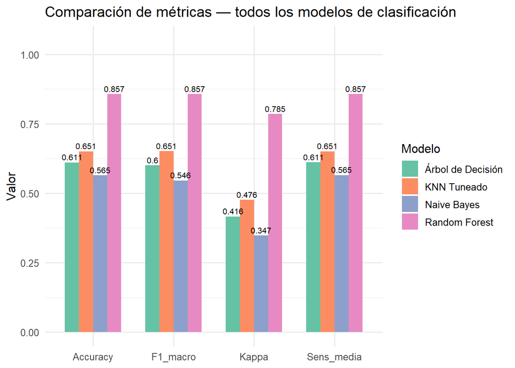

```r
tabla_long <- tabla_final_clf %>%
  tidyr::pivot_longer(cols = c(Accuracy, Kappa, F1_macro, Sens_media),
                      names_to = "Metrica", values_to = "Valor")

ggplot(tabla_long, aes(x = Metrica, y = Valor, fill = Modelo)) +
  geom_col(position = "dodge", width = 0.7) +
  geom_text(aes(label = round(Valor, 3)),
            position = position_dodge(width = 0.7),
            vjust = -0.4, size = 2.8) +
  scale_fill_brewer(palette = "Set2") +
  labs(title = "Comparación de métricas — todos los modelos de clasificación",
       x = NULL, y = "Valor", fill = "Modelo") +
  theme_minimal(base_size = 12) +
  expand_limits(y = 1.05)
```

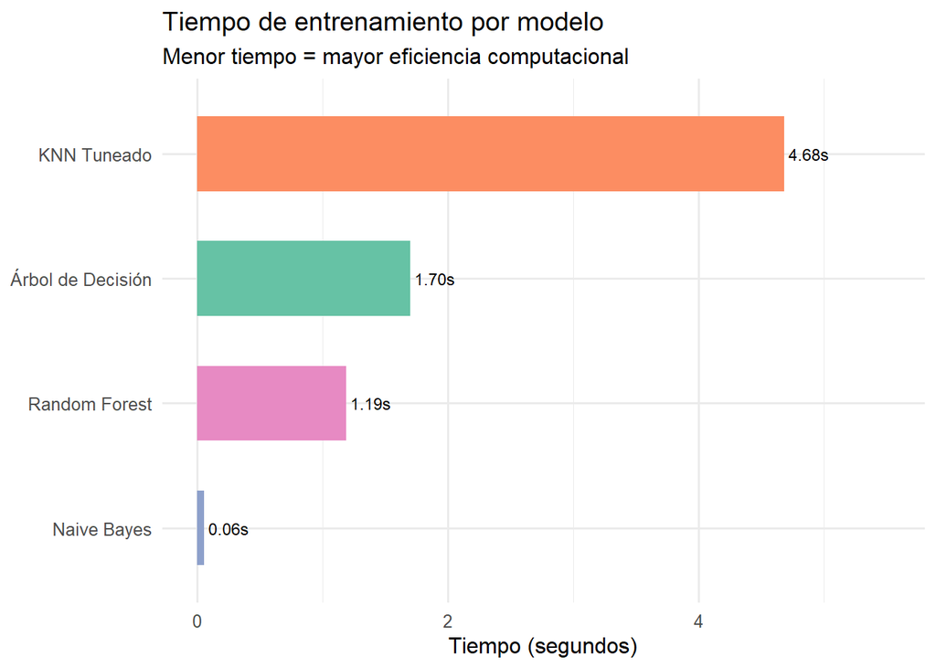

```r
ggplot(tabla_final_clf, aes(x = reorder(Modelo, Tiempo_seg),
                            y = Tiempo_seg, fill = Modelo)) +
  geom_col(show.legend = FALSE, width = 0.6) +
  geom_text(aes(label = sprintf("%.2fs", Tiempo_seg)),
            hjust = -0.1, size = 3.2) +
  coord_flip() +
  scale_fill_brewer(palette = "Set2") +
  labs(title    = "Tiempo de entrenamiento por modelo",
       subtitle = "Menor tiempo = mayor eficiencia computacional",
       x = NULL, y = "Tiempo (segundos)") +
  theme_minimal(base_size = 12) +
  expand_limits(y = max(tabla_final_clf$Tiempo_seg) * 1.18)
```

```r
tiempos <- tabla_final_clf %>% select(Modelo, Tiempo_seg) %>% arrange(Tiempo_seg)

knitr::kable(tiempos,
             col.names = c("Modelo","Tiempo (s)"),
             caption   = "Tiempos de entrenamiento ordenados (más rápido a más lento)",
             align     = c("l","r")) %>%
  kable_styling(bootstrap_options = c("striped","condensed"), full_width = FALSE) %>%
  row_spec(which.max(tiempos$Tiempo_seg), bold = TRUE, background = "#fee090")
```

Tiempos de entrenamiento ordenados (más rápido a más lento)

|  | Modelo | Tiempo (s) |
| --- | --- | --- |
| Accuracy2 | Naive Bayes | 0.057 |
| Accuracy1 | Random Forest | 1.191 |
| Accuracy | Árbol de Decisión | 1.703 |
| Accuracy3 | KNN Tuneado | 4.682 |

```
## Mejor modelo de clasificación: Random Forest
```

```
## Accuracy: 0.8568
```

De los cuatro algoritmos evaluados, el modelo resaltado en verde en la Tabla 7 es el que clasifica con mayor precisión las categorías de precio sobre el conjunto de prueba.

**KNN Tuneado** ofrece un balance entre interpretabilidad y desempeño. Su limitación principal es el costo de predicción, que escala con el tamaño del conjunto de entrenamiento.

**Naive Bayes** es el modelo más simple y más rápido, pero la asunción de independencia entre variables predictoras lo penaliza cuando las variables están correlacionadas.